# Settling in France: The healthcare system

The public healthcare system here is amazing

french bureaucracy

Nancy

going to France

Published

November 24, 2021

> It is mandatory for all residents in France to register into the French healthcare system.

Here you can tell they really see healthcare as a human right.

> The official [Campus France guide](https://www.campusfrance.org/en/registering-to-social-security) is very helpful.

# Setting it up

Getting everything set up is really slow, but after that everything is really smooth. In my case everything took around 5 months to set up, but for other students it got to 8 months.

## Steps and documents

The stages to get into the healthcare system are:

- Initial registration
- Getting a provisional number
- Getting a definitive number
- Applying for a *Carte Vitale*
- Optional: Getting a *mutuelle* insurance
- Optional: Applying for the *Complemaintaire*

The documents necessary along the way are: - Passport - Residence permit - Proof of registration at a University for the current academic year - Birth certificate in the original language, translated if possible - IBAN bank account number - A French phone number

## Initial registration

It is reallly important to do this ASAP after arriving to France, as the whole process is slown. Luckily, the initial registration completely online and really straight forward.

1. Go to the [website for social security registration for foreign students](https://etudiant-etranger.ameli.fr/#/).
2. Specify your situation, date of birth, and nationality.
   - Note: I have heard some nationalities, like Canada, have different registration processes due to agreements with France. In any case, the website is really user-friendly and will guide you in everything you need.
3. As an LCT student with a scholarship, my situation was “Student without employment”
4. Then you will be prompted to a list of necessary documents:

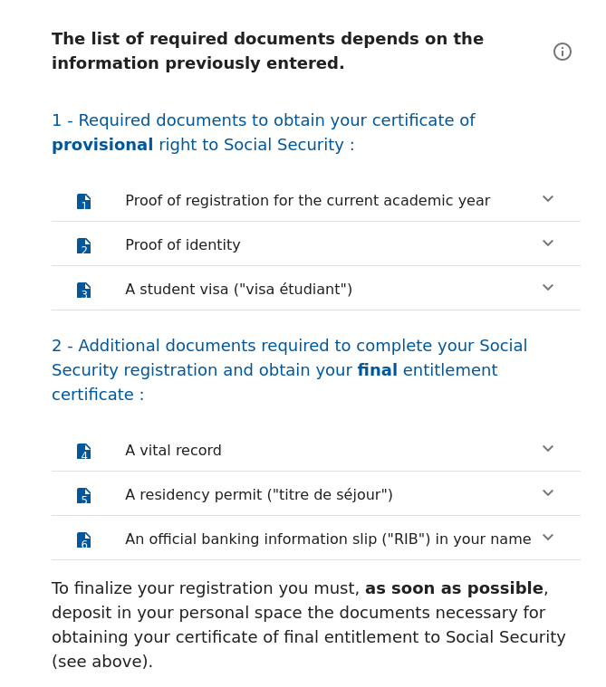

They also explain what they mean by a “vital record”:

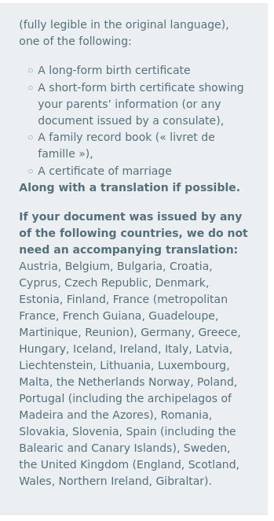

- The “vital record” I used was my birth certificate in Spanish.
5. After the prompt with all the necessary documents, you will be asked to create an account. Here, a French phone number is necessary.
6. Then you will be asked to upload the documents. If you don’t have one available, you can always log in later to upload it.

So, one mistake I made here was to wait until I had a bank account number (which took approximately one month) to start with the procedure. As the instructions on the website point out, there are two stages to get registered: - getting a provisional social security number - getting a definitive social security number

It would have been faster for me if I had uploaded the documents for the provisional number as soon as I arrived in France. It is only after getting the provisional number that the process for a definitive number starts, so, I really did not have to wait until I had all the necessary documents for the definitive number.

Anyway, after uploading the documents, you will see a “Processing” sign next to them. With this, the initial registration is done, and now you have to cross your fingers wishing they don’t take long to process them.

## Getting a provisional number

After the initial registration, you just have to wait until they send you a letter in the mail with your provisional number.

In my case, it took approximately two months to get this letter.

However, other students had to wait for four to six months. In those cases, it was better to go to the social security office (called *Caisse Primaire d’Assurance Maladie (CPAM)*) and ask for the status of the process.

- Even though in the websites of all *CPAM*s in France it says that you can only go there with an appointment (*rendez-vous*), you can really just go and wait in line.
- It is way better to go with a native French speaker to help you, or even better, someone from France, who know a little more about the bureaucracy in this country.
- In some cases, the *CPAM* had lost the uploaded documents, so some classmates had to show those documents in physical form there.
- In some other cases, everything was fine, they were just being really slow with the documents. This was even slower with those documents written in a non-Latin script.

Provisional numbers start with `7`, and once you get them you can go to the doctor. However, you will have to pay full price out-of-pocket, which is **25 €** for an appointment with a general practitioner (I don’t know how much specialists charge). After that, there is a process where you can mail the receipt and some form in order to be partially reimbursed (I never had to do that because my definitive number didn’t take that long to arrive).

Once, you get a definitve number, it is way easier to go see a doctor.

## Getting a definitive number

Approximately one month after getting my provisional number, I got another letter in the mail with my definitive number. From what I have heard from other students, this was a really short time.

With the definitive number, you can go to see a doctor and have the social security system partially cover your expenses. For example, for appointments with general practitioners, **60-70%** is covered, so I ended up paying only **7 €** per appointment.

In the same letter that notifed me about my definitive number, I received a form to apply for a *Carte Vitale*.

### Creating an *Ameli.fr* account

[*Ameli.fr*](https://www.ameli.fr/) is the website of the social security system in France. After getting the definitive number, you can use it create an account there to follow your medical history (including reimbursements). You can also use it to do some bureaucracy. It is only available in French.

[figure not shown]

### Using *FranceConnect*

[*FranceConnect*](https://franceconnect.gouv.fr/) is an identification and authentification service from the French government. In short, it makes it so that you only need one account to do all the online bureaucracy, instead of creating an account for every public service.

You can use your *Ameli.fr* account to create a *FranceConnect* account!

[figure not shown]

## Applying for a *Carte Vitale*

A *Carte Vitale* is just a card with your definitive social security number and your photo, which serves a proof of your registration in the French social security system.

Once you have a *Carte Vitale*, when you go to a doctor’s appointment or a pharmacy, they just scan it and the partial coverage is automatically applied!

As I said, the form to apply for a *Carte Vitale* arrived in the same letter as my definitive number. This form is really easy to fill, I only needed - a photocopy of my passport - an ID photo - a signature

Along with the form came an envelope and an address. I had to use this envelope to mail them the filled form back. Luckily, the envelope came already stamped, so I did not have to pay anything to send it back. I just went to a *La Poste* office, asked where to deposit my letter, and that was it.

> Note: Once you get the form you only have 15 days to send it filled over the mail

After sending the form, I received my *Carte Vitale* in the mail in one month.

### Optional: getting a European Health Insurance Card

Once you have a *Carte Vitale* you can request an [European Health Insurance Card - EHIC](https://www.cleiss.fr/particuliers/ceam_en.html) using your *Ameli.fr* account. This card may be useful for having health coverage if you are travelling outside of France.

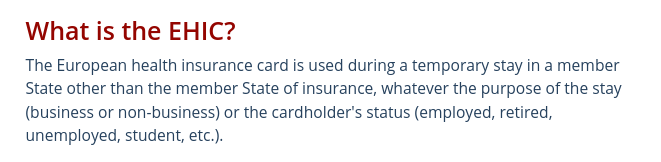

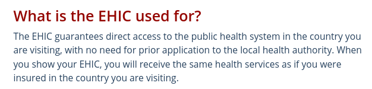

After requesting it, I had to wait for two weeks for it to arrive in the mail.

## Declaring a *médecin traitant*

A *médecin traitant* is just your general practitioner doctor. In order to have the reimbursements work smoothly, you should declare one.

In the same letter where my definitive number came, I got a form to declare a *médecin traitant*. I had to look for a doctor who spoke English or Spanish in *Doctolib* (see below).

Once in the appointment, I had to ask the doctor to become my *médecin traitant*, they accepted and registered it in the system in just a couple of seconds.

## Optional: Getting a *mutuelle*

The coverage of the French social security system is *partial*: you will still have to pay for doctor appointments, medicine, etc. To cover the remaining part of the cost, the French use a *mutuelle*, which is a kind of personal insurance, usually pay monthly.

As an LCT student, I had an insurance provided by the programme, so I did **not** have to subscribe to a *mutuelle*. I am including it here for completeness.

## Optional: Applying for the *Complementaire*

Again, the coverage of the French social security sytem is *partial*. Of course, each person has different economic circumsntances. The *Complementaire* exists for people who do not have enough ressources for covering all their health expenses: it entitles the holder for **total** coverage in some cases.

In general, one should apply for the *Complementaire* online, but this service does not work for foreing residents in France: One has to deposit the necessary documents in the *CPAM* in person.

I first had to go to the *CPAM* to ask for the necessary documents, and they gave me the following list for my particular situation (foreign student):

- Passport photocopy
- Student Visa photocopy
- Certificate of enrolment in a French university
- Certificate of *CAF* benefits (student housing subsidy) (to be explained in a future post)
- Tax history in France *or* a sworn declaration of having no tax history in France
- Residence Certificate (recent: < 3 months) : I got it at the reception in my residence
- Proof of scholarship : I used the Erasmus Mundus scholarship letter
- Student card photocopy
- Proof of coverage by the public health system : *Attestation de droits* that I downloaded from my *Ameli.fr* account.
- The application form for the *Complementaire*

The application form for the *Complementaire* can be found online, in the *Ameli.fr* website. It is a little complicated to understand, so I recommend filling it with the help of a French speaker.

Note: - One has to declare income of the last year. As I had not been working for more than a year by the time I applied to the *Complementaire*, the Erasmus scholarship was my only income.

- Since I was a foreign student in France, I had not payed any taxes ever in France, so I had to write a sworn declaration stating that fact. I used a simple model:

```python
"""
Attestation sur l’honneur de non-imposition

Je soussigné <M./Mme MY LAST NAME my name> demeurant <my address>,
Atteste sur l’honneur ne pas être soumis à l’impôt au titre des revenus de l’année 2020/2021.
Pour faire valoir ce que de droit

A Nancy, le ________________

""";
```

It roughly says “I declare under oath that I have not been subject to taxation during the years 2020/2021”

After having all the documents ready, I put them in an envelope and went with a francophone friend to the *CPAM*. There they told me to just deposit it on a box they had outside the building. Since I did not have an appointment, they told me they could not help me verify if my application was complete.

Luckily, two months after this, I got a notification on my *Ameli.fr* account showing that my application had been accepted!

To start using the *Complementaire* it is necessary to go to a *Pharmacie* (see below) and ask for them to update your *Carte Vitale*. This only takes a few seconds.

Finally, when I went to another medical appointment, I had to pay from my own money but was reimboursed within a week!

# Using the French healthcare system

As I have stated above, you can start getting coverage from the French social security system as soon as you have your provisional number, though it may be complicated until you get a *Carte Vitale*, after which it is really simple.

## Doctolib

Most people use [*Doctolib*](https://www.doctolib.fr/) to book doctor appointments in France. They have a website and mobile apps. Here, you can look up general practitioners and specialists. You can even filter doctors by which language they speak.

*Doctolib* is really easy to use, I’d recommend it!

The alternative to *Doctolib* is to call into a doctor’s office and request an appointment.

Note: you can use *Doctolib* without being registered in the social security system. In fact, this is what I did to reserve appointments for vaccination agains COVID (to be explained in a future post)

## Pharmacies

In France, unlike many countries, pharmacies are not a business, they are all about medicine and treaments.

You come in with your *ordonnance* (prescription), hand it in, show the *Carte Vitale*, and in a couple of minutes you will be walking out of the pharmacy with all you need.

In other countries I have seen pharmacies being run as convenience stores, so, for example, the clerks would offer you extra products to buy, or only give you information about cheaper medicine if you ask specifically ask for it. Not in France.

They are not difficult to find, however, they have somewhat inconvenient openning hours. Don’t worry, at any time outside of business hours it is guaranteed that at least one pharmacy will be open in the city. You can check which pharmacy is currently “standing guard” (*Pharmacie de Garde*) in the [3237 Pharmacie hotline website](https://www.3237.fr/). These pharmacies are the only ones where the waiting line may be really long, though.

There is a pharmacy really close to my Student Residence:

[interactive chart not shown]